# Implementing CNN

In this notebook, we are going to use the mel-scaled extracted features as an input for the Convolutionla Neural Networks(CNN)

## Basic setup

```python
!pip install keras
```

```python
!pip install tensorflow
```

```python
import pandas as pd
import numpy as np
from sklearn.model_selection import KFold
from sklearn.model_selection import train_test_split
from sklearn.metrics import confusion_matrix
from sklearn.preprocessing import LabelEncoder
from tensorflow.keras.models import Sequential
from tensorflow.keras.layers import Conv2D, MaxPooling2D, Flatten, Dense, Dropout, SpatialDropout2D
from tensorflow.keras.utils import to_categorical
import keras
from keras.optimizers import Adam
from keras import models, layers
from keras import regularizers
from keras import optimizers
import matplotlib.pyplot as plt
import seaborn as sns
import os
```

```python
# Diretory
os.chdir(r'Downloads')
```

[output not shown]

```python
urbansound8_path = os.path.abspath('./UrbanSound8K' )
data_path = os.path.join(urbansound8_path, 'data')
```

```python
X = np.load('UrbanSound8K/data/X-mel_spec.npy')  # Features
y_str = np.load('UrbanSound8K/data/y-mel_spec.npy')  # String labels
X = X.reshape(X.shape[0], X.shape[1], X.shape[2], 1)  # Add a channel dimension

# y-preprocessing
label_encoder = LabelEncoder()
y_int = label_encoder.fit_transform(y_str)
y = to_categorical(y_int)
```

```python
# Use the 10-fold classification
num_folds = 10
kfold = KFold(n_splits=num_folds, shuffle=False)
```

```python
input_shape = X.shape[1:]  # Exclude sample dimension
num_classes = y.shape[1]  # Number of unique classes
```

```python
print(input_shape)
```

```
(40, 174, 1)
```

```python
print(num_classes)
```

```
10
```

## Model definition

For our CNN, we are going to use the mel-scaled features as input, with shape (40, 174, 1).  
We start by defining a sequential model where we add 2D convolutional layers with 32 filters and a "relu" function as the activation function.  
Then we add max pooling layers with a pool size of 2x2 in order to reduce the spatial dimensions of the input.  
To prevent overfitting, we procede to use SpatialDropout2D() by dropping entire 2D feature maps.  
At the end, we added a flattening layer that converts the 2D feature maps into a 1D array and a dense (fully connected) layer with 128 neurons and 'relu' activation.  
Finally, we added another dense layer with a number of neurons equal to num_classes and use the 'softmax' activation function. This layer outputs the probability distribution of each class.

```python
# Creating the model we are going to use later

def create_model(input_shape, num_classes):
    # Create a sequential object
    model = Sequential()

    model.add(Conv2D(filters=32, kernel_size=(3, 3), activation="relu", input_shape=input_shape))
    model.add(MaxPooling2D(2,2))
    model.add(SpatialDropout2D(0.10, input_shape=input_shape))


    model.add(Conv2D(filters=32, kernel_size=(3, 3), activation="relu"))
    model.add(MaxPooling2D(2,2))
    model.add(SpatialDropout2D(0.20, input_shape=input_shape))

    model.add(Flatten())
    model.add(Dense(128, activation='relu'))
    model.add(Dense(num_classes, activation='softmax'))

    return model
```

```python
fold_n = 1 # Starting fold
num_epochs = 20
all_folds_history = [] # Keeps all accuracy and loss values for each epoch to help
confusion_matrices = [] # Keeps all the confusion matrices
for train, test in kfold.split(X, y):

    model = create_model(input_shape, num_classes)
    model.compile(optimizer='adam', loss='categorical_crossentropy', metrics=['accuracy'])
    model.summary() # Shows a summary of the model built

    # Train the model
    print(f'Training for fold {fold_n} ...')

    # Train the model and save the history
    history = model.fit(X[train], y[train], epochs=num_epochs, batch_size=32)
    all_folds_history.append(history)

    # Evaluate the model
    scores = model.evaluate(X[test], y[test], verbose=0)
    print(f'Score for fold {fold_n}: loss of {scores[0]}; accuracy of {scores[1]*100}%')

    # Builds the confusion matrix of the model
    predictions = model.predict(X[test])
    predicted_classes = np.argmax(predictions, axis=1)
    true_classes = np.argmax(y[test], axis=1)
    cm = confusion_matrix(true_classes, predicted_classes)
    confusion_matrices.append(cm)

    del model

    fold_n += 1
```

```
Model: "sequential_4"
_________________________________________________________________
 Layer (type)                Output Shape              Param #
=================================================================
 conv2d_8 (Conv2D)           (None, 38, 172, 32)       320

 max_pooling2d_8 (MaxPoolin  (None, 19, 86, 32)        0
 g2D)

 spatial_dropout2d_8 (Spati  (None, 19, 86, 32)        0
 alDropout2D)

 conv2d_9 (Conv2D)           (None, 17, 84, 32)        9248

 max_pooling2d_9 (MaxPoolin  (None, 8, 42, 32)         0
 g2D)

 spatial_dropout2d_9 (Spati  (None, 8, 42, 32)         0
 alDropout2D)

 flatten_4 (Flatten)         (None, 10752)             0

 dense_8 (Dense)             (None, 128)               1376384

 dense_9 (Dense)             (None, 10)                1290

=================================================================
Total params: 1387242 (5.29 MB)
Trainable params: 1387242 (5.29 MB)
Non-trainable params: 0 (0.00 Byte)
_________________________________________________________________
Training for fold 1 ...
Score for fold 1: loss of 1.8901666402816772; accuracy of 75.62928795814514%
Model: "sequential_5"
_________________________________________________________________
 Layer (type)                Output Shape              Param #
=================================================================
 conv2d_10 (Conv2D)          (None, 38, 172, 32)       320

 max_pooling2d_10 (MaxPooli  (None, 19, 86, 32)        0
```

[output cut: 275 more lines]

```
 ialDropout2D)

 flatten_13 (Flatten)        (None, 10752)             0

 dense_26 (Dense)            (None, 128)               1376384

 dense_27 (Dense)            (None, 10)                1290

=================================================================
Total params: 1387242 (5.29 MB)
Trainable params: 1387242 (5.29 MB)
Non-trainable params: 0 (0.00 Byte)
_________________________________________________________________
Training for fold 10 ...
Score for fold 10: loss of 1.8117880821228027; accuracy of 74.45589900016785%
```

## Performance evaluation

```python
# Builds a graphical version of the confusion matrix
def build_cm(cm, title, cmap):
    plt.figure(figsize=(5, 4))
    sns.heatmap(cm, annot=True, fmt='d', cmap=cmap)
    plt.title(title)
    plt.ylabel('True Label')
    plt.xlabel('Predicted Label')
    plt.tight_layout()
    plt.show()
```

```python
# Plotting the accuracy and loss functions
def build_stats(history, epochs_range, i):
    plt.figure(figsize=(12, 5))

    # Building accuracy graphic
    plt.subplot(1, 2, 1)
    plt.plot(epochs_range, history.history['accuracy'], label='Training Accuracy', color = 'green')
    plt.title(f'Fold {i+1} - Training Accuracy')
    plt.xlabel('Epochs')
    plt.ylabel('Accuracy')
    plt.legend()

    # Building loss graphic
    plt.subplot(1, 2, 2)
    plt.plot(epochs_range, history.history['loss'], label='Training Loss', color = 'red')
    plt.title(f'Fold {i+1} - Training Loss')
    plt.xlabel('Epochs')
    plt.ylabel('Loss')
    plt.legend()

    # Display the plot
    plt.tight_layout()
    plt.show()
```

### Confusion Matrices

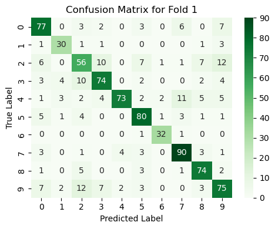

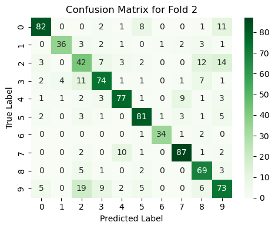

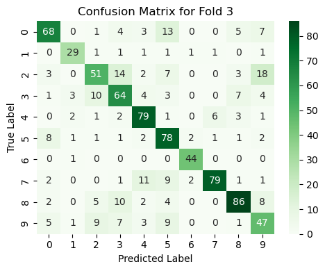

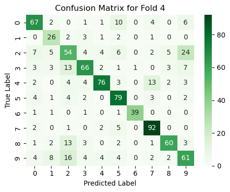

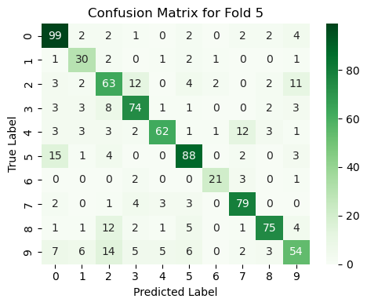

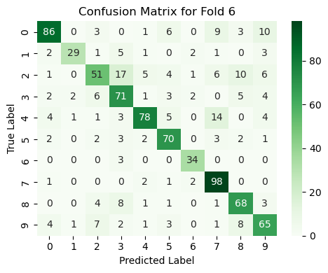

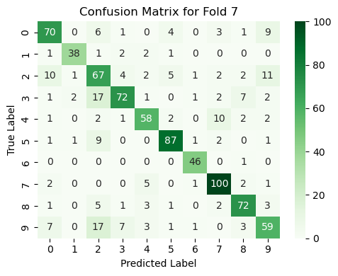

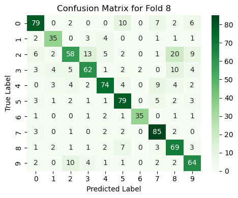

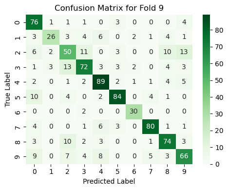

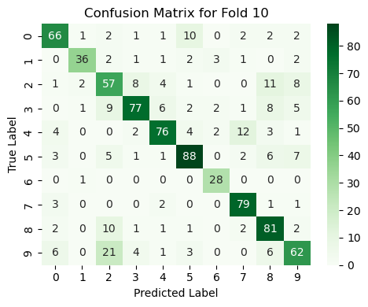

```python
for i in range (0, num_folds):
    build_cm(confusion_matrices[i], f'Confusion Matrix for Fold {i+1}', 'Greens')
```

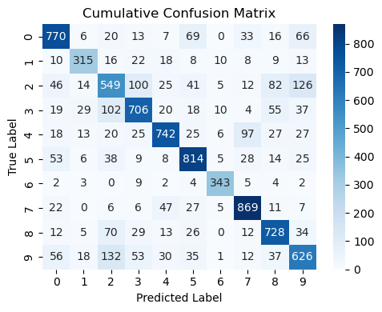

```python
cumulative_confusion_matrix = np.sum(confusion_matrices, axis=0)
build_cm(cumulative_confusion_matrix, "Cumulative Confusion Matrix", 'Blues')
```

### Accuracy and loss values while training the model

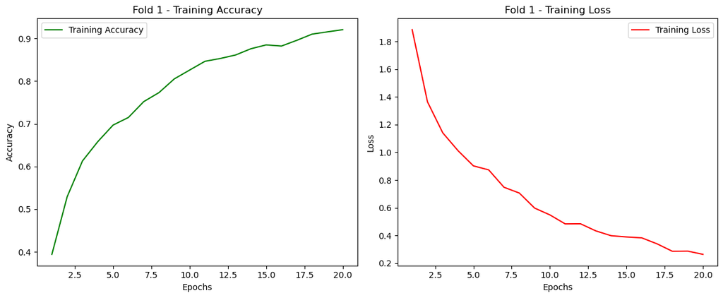

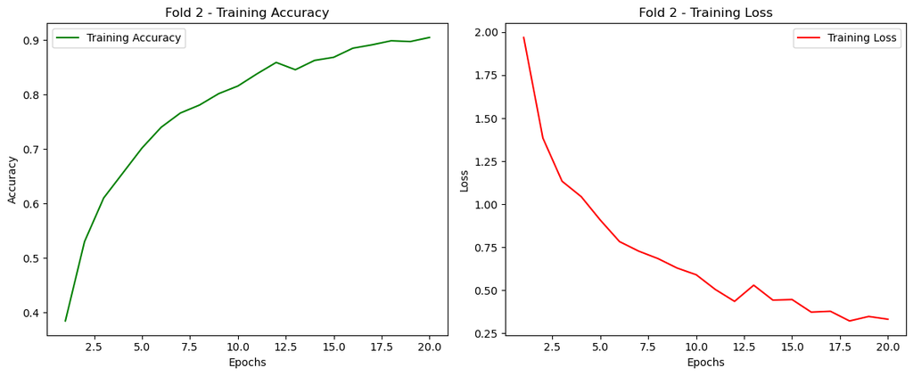

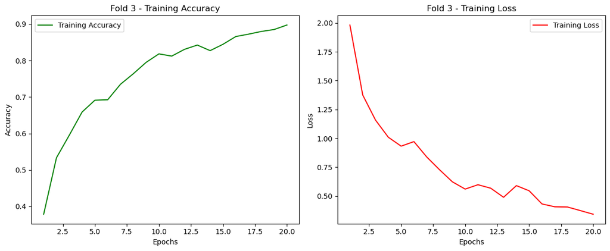

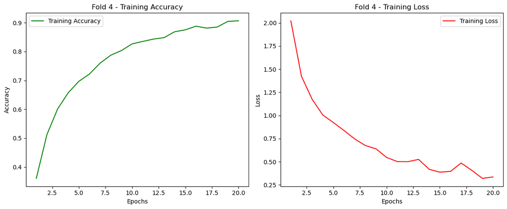

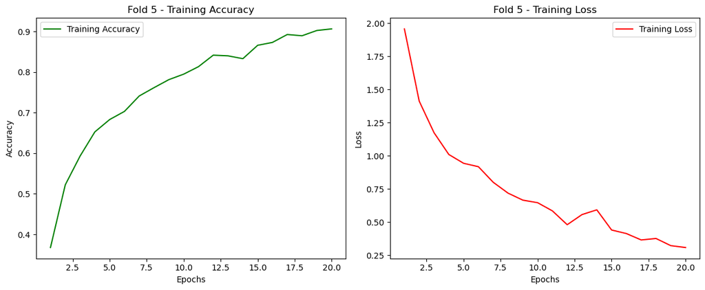

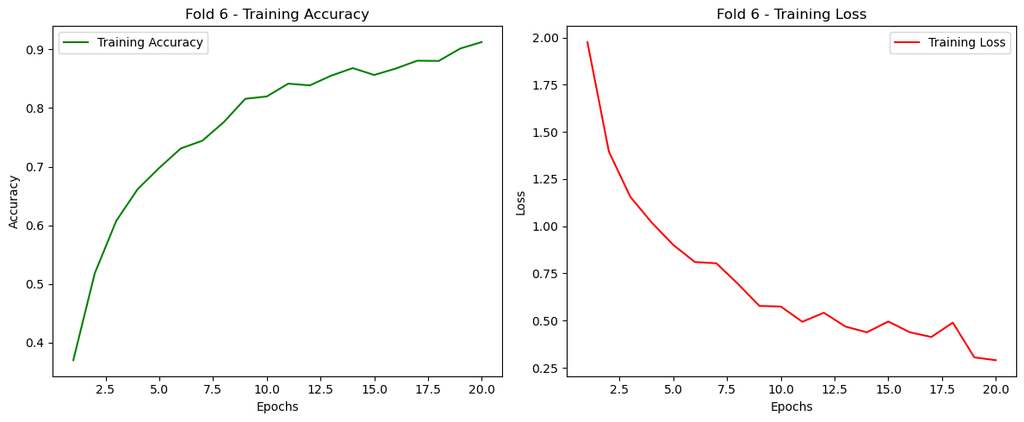

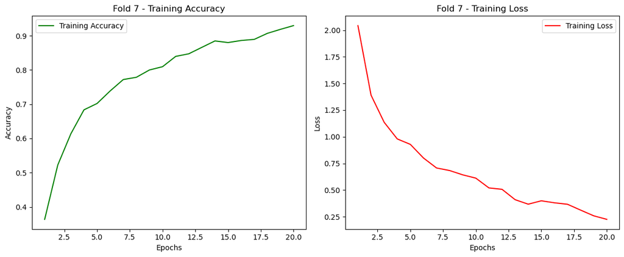

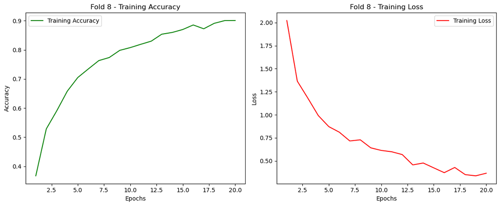

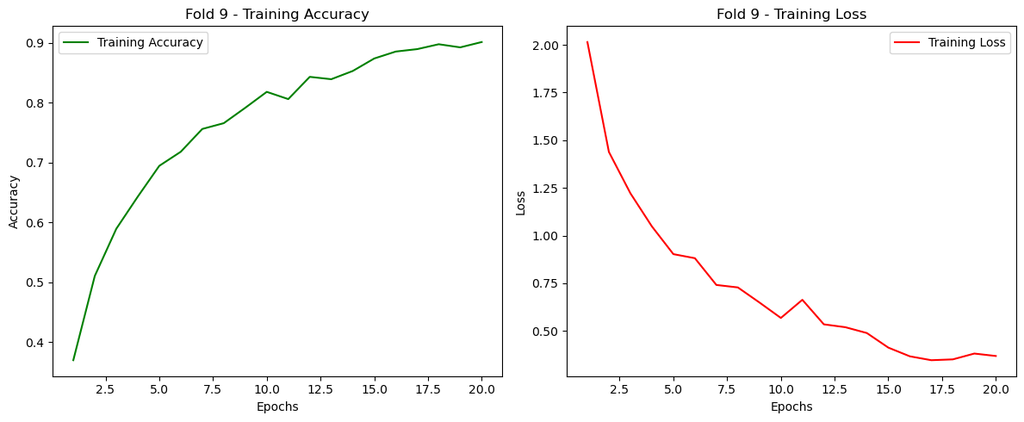

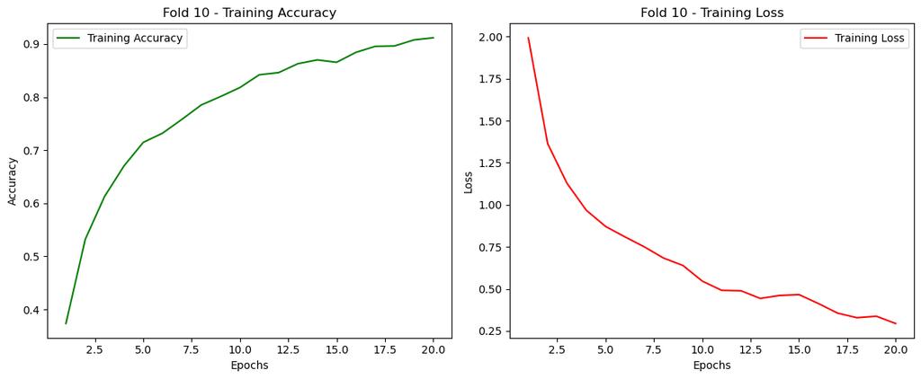

```python
num_epochs = 20
epochs_range = range(1, num_epochs + 1)
for i in range (0, num_folds):
    build_stats(all_folds_history[i], epochs_range, i)
```

### Accuracy per class

```python
# Calculating class-wise accuracy
class_accuracies = np.diagonal(cumulative_confusion_matrix) / np.sum(cumulative_confusion_matrix, axis=1)
labels = [
        'Air Conditioner',
        'Car Horn',
        'Children Playing',
        'Dog bark',
        'Drilling',
        'Engine Idling',
        'Gun Shot',
        'Jackhammer',
        'Siren',
        'Street Music'
    ]

# Building a dataframe with the mels results
results_mels = pd.DataFrame({
    'CLASS': labels,
    'ACCURACY': class_accuracies
})
results_mels.to_csv('results_mels.csv', index=False)

results_mels
```

|  | CLASS | ACCURACY |
| --- | --- | --- |
| 0 | Air Conditioner | 0.770000 |
| 1 | Car Horn | 0.734266 |
| 2 | Children Playing | 0.549000 |
| 3 | Dog bark | 0.706000 |
| 4 | Drilling | 0.742000 |
| 5 | Engine Idling | 0.814000 |
| 6 | Gun Shot | 0.917112 |
| 7 | Jackhammer | 0.869000 |
| 8 | Siren | 0.783638 |
| 9 | Street Music | 0.626000 |

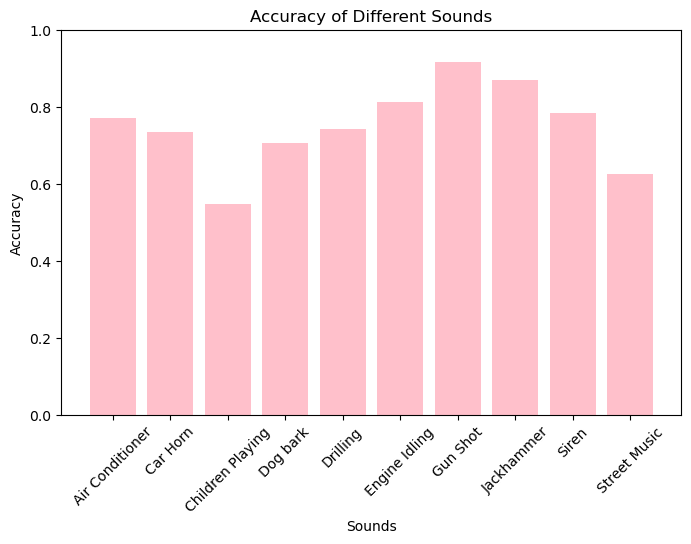

```python
# Plotting the accuracies
plt.figure(figsize=(8, 5))
plt.bar(results_mels['CLASS'], results_mels['ACCURACY'], color='pink')
plt.xlabel('Sounds')
plt.ylabel('Accuracy')
plt.title('Accuracy of Different Sounds')
plt.xticks(rotation=45)  # Rotating the x-axis labels for better readability
plt.ylim(0, 1)  # Setting the y-axis limit from 0 to 1 as accuracy ranges between 0 and 100%
plt.show()
```